# Risk Factor Analysis

## Outcome Variable

**Outcome Variable:** ever_co

## Predictor Variables

**Intervention Variable:** hdlvry

**Adjustment Set:**

- arm
- sex
- W_mage
- meducyrs
- feducyrs
- hhwealth_quart
- single
- W_nrooms
- brthmon
- W_parity
- impsan
- delta_W_mage
- delta_meducyrs
- delta_feducyrs
- delta_hhwealth_quart
- delta_single
- delta_W_nrooms
- delta_brthmon
- delta_W_parity
- delta_impsan

## Stratifying Variables

The analysis was stratified on these variable(s):

- agecat
- studyid
- country

## Data Summary

| agecat | studyid | country | hdlvry | ever_co | n_cell | n |
| --- | --- | --- | --- | --- | --- | --- |
| 0-24 months | CMC-V-BCS-2002 | INDIA | 0 | 0 | 279 | 370 |
| 0-24 months | CMC-V-BCS-2002 | INDIA | 0 | 1 | 83 | 370 |
| 0-24 months | CMC-V-BCS-2002 | INDIA | 1 | 0 | 7 | 370 |
| 0-24 months | CMC-V-BCS-2002 | INDIA | 1 | 1 | 1 | 370 |
| 0-24 months | COHORTS | INDIA | 0 | 0 | 2904 | 5089 |
| 0-24 months | COHORTS | INDIA | 0 | 1 | 232 | 5089 |
| 0-24 months | COHORTS | INDIA | 1 | 0 | 1679 | 5089 |
| 0-24 months | COHORTS | INDIA | 1 | 1 | 274 | 5089 |
| 0-24 months | EE | PAKISTAN | 0 | 0 | 143 | 377 |
| 0-24 months | EE | PAKISTAN | 0 | 1 | 110 | 377 |
| 0-24 months | EE | PAKISTAN | 1 | 0 | 65 | 377 |
| 0-24 months | EE | PAKISTAN | 1 | 1 | 59 | 377 |
| 0-24 months | GMS-Nepal | NEPAL | 0 | 0 | 118 | 637 |
| 0-24 months | GMS-Nepal | NEPAL | 0 | 1 | 38 | 637 |
| 0-24 months | GMS-Nepal | NEPAL | 1 | 0 | 335 | 637 |
| 0-24 months | GMS-Nepal | NEPAL | 1 | 1 | 146 | 637 |
| 0-24 months | IRC | INDIA | 0 | 0 | 328 | 410 |
| 0-24 months | IRC | INDIA | 0 | 1 | 74 | 410 |
| 0-24 months | IRC | INDIA | 1 | 0 | 6 | 410 |
| 0-24 months | IRC | INDIA | 1 | 1 | 2 | 410 |
| 0-24 months | JiVitA-3 | BANGLADESH | 0 | 0 | 40 | 350 |
| 0-24 months | JiVitA-3 | BANGLADESH | 0 | 1 | 2 | 350 |
| 0-24 months | JiVitA-3 | BANGLADESH | 1 | 0 | 276 | 350 |
| 0-24 months | JiVitA-3 | BANGLADESH | 1 | 1 | 32 | 350 |
| 0-24 months | JiVitA-4 | BANGLADESH | 0 | 0 | 1007 | 4501 |
| 0-24 months | JiVitA-4 | BANGLADESH | 0 | 1 | 164 | 4501 |
| 0-24 months | JiVitA-4 | BANGLADESH | 1 | 0 | 2757 | 4501 |
| 0-24 months | JiVitA-4 | BANGLADESH | 1 | 1 | 573 | 4501 |
| 0-24 months | NIH-Crypto | BANGLADESH | 0 | 0 | 545 | 758 |
| 0-24 months | NIH-Crypto | BANGLADESH | 0 | 1 | 45 | 758 |

[output cut: 114 more lines]

The following strata were considered:

- agecat: 0-24 months, studyid: CMC-V-BCS-2002, country: INDIA
- agecat: 0-24 months, studyid: COHORTS, country: INDIA
- agecat: 0-24 months, studyid: EE, country: PAKISTAN
- agecat: 0-24 months, studyid: GMS-Nepal, country: NEPAL
- agecat: 0-24 months, studyid: IRC, country: INDIA
- agecat: 0-24 months, studyid: JiVitA-3, country: BANGLADESH
- agecat: 0-24 months, studyid: JiVitA-4, country: BANGLADESH
- agecat: 0-24 months, studyid: NIH-Crypto, country: BANGLADESH
- agecat: 0-24 months, studyid: PROVIDE, country: BANGLADESH
- agecat: 0-24 months, studyid: SAS-CompFeed, country: INDIA
- agecat: 0-24 months, studyid: SAS-FoodSuppl, country: INDIA
- agecat: 0-24 months, studyid: TanzaniaChild2, country: TANZANIA, UNITED REPUBLIC OF
- agecat: 0-6 months, studyid: CMC-V-BCS-2002, country: INDIA
- agecat: 0-6 months, studyid: COHORTS, country: INDIA
- agecat: 0-6 months, studyid: EE, country: PAKISTAN
- agecat: 0-6 months, studyid: GMS-Nepal, country: NEPAL
- agecat: 0-6 months, studyid: IRC, country: INDIA
- agecat: 0-6 months, studyid: JiVitA-3, country: BANGLADESH
- agecat: 0-6 months, studyid: JiVitA-4, country: BANGLADESH
- agecat: 0-6 months, studyid: NIH-Crypto, country: BANGLADESH
- agecat: 0-6 months, studyid: PROVIDE, country: BANGLADESH
- agecat: 0-6 months, studyid: SAS-CompFeed, country: INDIA
- agecat: 0-6 months, studyid: SAS-FoodSuppl, country: INDIA
- agecat: 0-6 months, studyid: TanzaniaChild2, country: TANZANIA, UNITED REPUBLIC OF
- agecat: 6-24 months, studyid: CMC-V-BCS-2002, country: INDIA
- agecat: 6-24 months, studyid: COHORTS, country: INDIA
- agecat: 6-24 months, studyid: EE, country: PAKISTAN
- agecat: 6-24 months, studyid: GMS-Nepal, country: NEPAL
- agecat: 6-24 months, studyid: IRC, country: INDIA
- agecat: 6-24 months, studyid: JiVitA-3, country: BANGLADESH
- agecat: 6-24 months, studyid: JiVitA-4, country: BANGLADESH
- agecat: 6-24 months, studyid: NIH-Crypto, country: BANGLADESH
- agecat: 6-24 months, studyid: PROVIDE, country: BANGLADESH
- agecat: 6-24 months, studyid: SAS-CompFeed, country: INDIA
- agecat: 6-24 months, studyid: SAS-FoodSuppl, country: INDIA
- agecat: 6-24 months, studyid: TanzaniaChild2, country: TANZANIA, UNITED REPUBLIC OF

### Dropped Strata

Some strata were dropped due to rare outcomes:

- agecat: 0-24 months, studyid: CMC-V-BCS-2002, country: INDIA
- agecat: 0-24 months, studyid: IRC, country: INDIA
- agecat: 0-24 months, studyid: JiVitA-3, country: BANGLADESH
- agecat: 0-24 months, studyid: TanzaniaChild2, country: TANZANIA, UNITED REPUBLIC OF
- agecat: 0-6 months, studyid: CMC-V-BCS-2002, country: INDIA
- agecat: 0-6 months, studyid: IRC, country: INDIA
- agecat: 0-6 months, studyid: JiVitA-3, country: BANGLADESH
- agecat: 0-6 months, studyid: SAS-CompFeed, country: INDIA
- agecat: 0-6 months, studyid: SAS-FoodSuppl, country: INDIA
- agecat: 0-6 months, studyid: TanzaniaChild2, country: TANZANIA, UNITED REPUBLIC OF
- agecat: 6-24 months, studyid: CMC-V-BCS-2002, country: INDIA
- agecat: 6-24 months, studyid: IRC, country: INDIA
- agecat: 6-24 months, studyid: JiVitA-3, country: BANGLADESH
- agecat: 6-24 months, studyid: TanzaniaChild2, country: TANZANIA, UNITED REPUBLIC OF

## Methods Detail

We’re interested in the causal parameters $E[Y_a]$ for all values of $a \in \mathcal{A}$. These parameters represent the mean outcome if, possibly contrary to fact, we intervened to set all units to have $A=a$. Under the randomization and positivity assumptions, these are identified by the statistical parameters $\psi_a=E_W[E_{Y|A,W}(Y|A=a,W)]$. In addition, we’re interested in the mean of $Y$, $E[Y]$ under no intervention (the observed mean). We will estimate these parameters by using SuperLearner to fit the relevant likelihood factors – $E_{Y|A,W}(Y|A=a,W)$ and $p(A=a|W)$, and then updating our likelihood fit using a joint TMLE.

For unadjusted analyses ($W=\{\}$), initial likelihoods were estimated using Lrnr_glm to estimate the simple $E(Y|A)$ and Lrnr_mean to estimate $p(A)$. For adjusted analyses, a small library containing Lrnr_glmnet, Lrnr_xgboost, and Lrnr_mean was used.

Having estimated these parameters, we will then use the delta method to estimate relative risks and attributable risks relative to a prespecified baseline level of $A$.

# Results Detail

## Results Plots

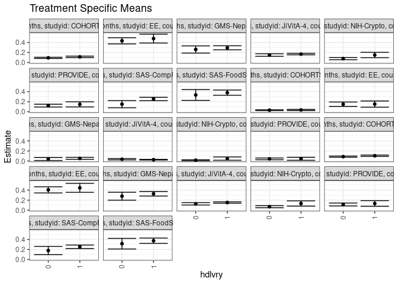

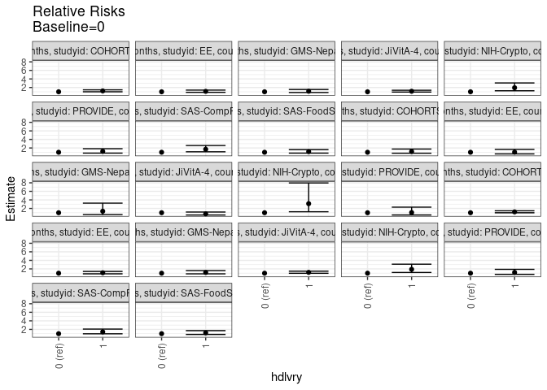

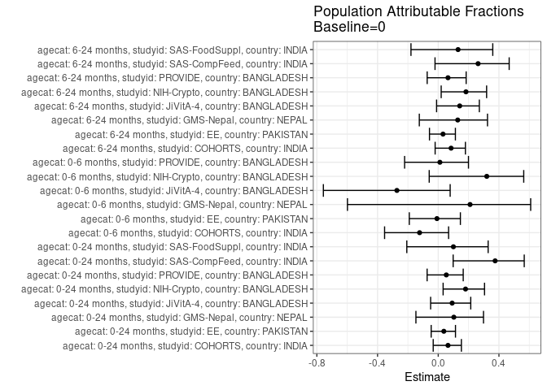

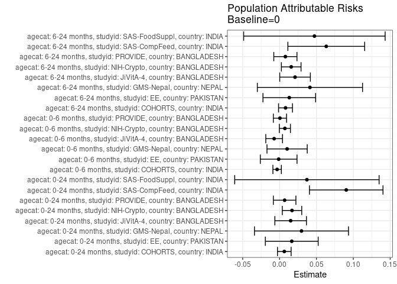

## Results Table

### Parameter: TSM

| agecat | studyid | country | intervention_level | baseline_level | estimate | ci_lower | ci_upper |
| --- | --- | --- | --- | --- | --- | --- | --- |
| 0-24 months | COHORTS | INDIA | 0 | NA | 0.0930408 | 0.0809859 | 0.1050956 |
| 0-24 months | COHORTS | INDIA | 1 | NA | 0.1120883 | 0.0968256 | 0.1273510 |
| 0-24 months | EE | PAKISTAN | 0 | NA | 0.4317715 | 0.3704553 | 0.4930877 |
| 0-24 months | EE | PAKISTAN | 1 | NA | 0.4766207 | 0.3881206 | 0.5651208 |
| 0-24 months | GMS-Nepal | NEPAL | 0 | NA | 0.2591632 | 0.1878359 | 0.3304905 |
| 0-24 months | GMS-Nepal | NEPAL | 1 | NA | 0.2925352 | 0.2518154 | 0.3332549 |
| 0-24 months | JiVitA-4 | BANGLADESH | 0 | NA | 0.1487415 | 0.1230214 | 0.1744617 |
| 0-24 months | JiVitA-4 | BANGLADESH | 1 | NA | 0.1670873 | 0.1530904 | 0.1810843 |
| 0-24 months | NIH-Crypto | BANGLADESH | 0 | NA | 0.0768180 | 0.0553508 | 0.0982853 |
| 0-24 months | NIH-Crypto | BANGLADESH | 1 | NA | 0.1491634 | 0.0955537 | 0.2027731 |
| 0-24 months | PROVIDE | BANGLADESH | 0 | NA | 0.1217491 | 0.0935669 | 0.1499314 |
| 0-24 months | PROVIDE | BANGLADESH | 1 | NA | 0.1470358 | 0.0960344 | 0.1980372 |
| 0-24 months | SAS-CompFeed | INDIA | 0 | NA | 0.1506913 | 0.0787609 | 0.2226218 |
| 0-24 months | SAS-CompFeed | INDIA | 1 | NA | 0.2542957 | 0.2210574 | 0.2875340 |
| 0-24 months | SAS-FoodSuppl | INDIA | 0 | NA | 0.3337812 | 0.2260351 | 0.4415273 |
| 0-24 months | SAS-FoodSuppl | INDIA | 1 | NA | 0.3800842 | 0.3278901 | 0.4322782 |
| 0-6 months | COHORTS | INDIA | 0 | NA | 0.0305312 | 0.0227932 | 0.0382692 |
| 0-6 months | COHORTS | INDIA | 1 | NA | 0.0354897 | 0.0241418 | 0.0468376 |
| 0-6 months | EE | PAKISTAN | 0 | NA | 0.1497997 | 0.1058563 | 0.1937431 |
| 0-6 months | EE | PAKISTAN | 1 | NA | 0.1525861 | 0.0907195 | 0.2144527 |
| 0-6 months | GMS-Nepal | NEPAL | 0 | NA | 0.0384615 | 0.0082604 | 0.0686627 |
| 0-6 months | GMS-Nepal | NEPAL | 1 | NA | 0.0519751 | 0.0321221 | 0.0718280 |
| 0-6 months | JiVitA-4 | BANGLADESH | 0 | NA | 0.0345513 | 0.0208552 | 0.0482474 |
| 0-6 months | JiVitA-4 | BANGLADESH | 1 | NA | 0.0253495 | 0.0188178 | 0.0318812 |
| 0-6 months | NIH-Crypto | BANGLADESH | 0 | NA | 0.0152542 | 0.0053581 | 0.0251504 |
| 0-6 months | NIH-Crypto | BANGLADESH | 1 | NA | 0.0476190 | 0.0153953 | 0.0798428 |
| 0-6 months | PROVIDE | BANGLADESH | 0 | NA | 0.0423892 | 0.0250433 | 0.0597351 |
| 0-6 months | PROVIDE | BANGLADESH | 1 | NA | 0.0441989 | 0.0142343 | 0.0741635 |
| 6-24 months | COHORTS | INDIA | 0 | NA | 0.0867029 | 0.0745425 | 0.0988633 |
| 6-24 months | COHORTS | INDIA | 1 | NA | 0.1040746 | 0.0902766 | 0.1178725 |
| 6-24 months | EE | PAKISTAN | 0 | NA | 0.4057667 | 0.3445391 | 0.4669942 |
| 6-24 months | EE | PAKISTAN | 1 | NA | 0.4464613 | 0.3570832 | 0.5358393 |
| 6-24 months | GMS-Nepal | NEPAL | 0 | NA | 0.2794258 | 0.1999089 | 0.3589428 |
| 6-24 months | GMS-Nepal | NEPAL | 1 | NA | 0.3275065 | 0.2820259 | 0.3729871 |
| 6-24 months | JiVitA-4 | BANGLADESH | 0 | NA | 0.1272948 | 0.1036440 | 0.1509455 |
| 6-24 months | JiVitA-4 | BANGLADESH | 1 | NA | 0.1531781 | 0.1394527 | 0.1669036 |
| 6-24 months | NIH-Crypto | BANGLADESH | 0 | NA | 0.0705367 | 0.0493589 | 0.0917145 |
| 6-24 months | NIH-Crypto | BANGLADESH | 1 | NA | 0.1342402 | 0.0822745 | 0.1862059 |
| 6-24 months | PROVIDE | BANGLADESH | 0 | NA | 0.1143021 | 0.0852751 | 0.1433290 |
| 6-24 months | PROVIDE | BANGLADESH | 1 | NA | 0.1346075 | 0.0791219 | 0.1900930 |
| 6-24 months | SAS-CompFeed | INDIA | 0 | NA | 0.1778289 | 0.0959710 | 0.2596868 |
| 6-24 months | SAS-CompFeed | INDIA | 1 | NA | 0.2523390 | 0.2170626 | 0.2876153 |
| 6-24 months | SAS-FoodSuppl | INDIA | 0 | NA | 0.3143656 | 0.2087514 | 0.4199797 |
| 6-24 months | SAS-FoodSuppl | INDIA | 1 | NA | 0.3735286 | 0.3204593 | 0.4265979 |

### Parameter: E(Y)

| agecat | studyid | country | intervention_level | baseline_level | estimate | ci_lower | ci_upper |
| --- | --- | --- | --- | --- | --- | --- | --- |
| 0-24 months | COHORTS | INDIA | NA | NA | 0.0994301 | 0.0912079 | 0.1076524 |
| 0-24 months | EE | PAKISTAN | NA | NA | 0.4482759 | 0.3980083 | 0.4985434 |
| 0-24 months | GMS-Nepal | NEPAL | NA | NA | 0.2888540 | 0.2536300 | 0.3240780 |
| 0-24 months | JiVitA-4 | BANGLADESH | NA | NA | 0.1637414 | 0.1510998 | 0.1763830 |
| 0-24 months | NIH-Crypto | BANGLADESH | NA | NA | 0.0936675 | 0.0729118 | 0.1144233 |
| 0-24 months | PROVIDE | BANGLADESH | NA | NA | 0.1285714 | 0.1037574 | 0.1533855 |
| 0-24 months | SAS-CompFeed | INDIA | NA | NA | 0.2410714 | 0.1975050 | 0.2846379 |
| 0-24 months | SAS-FoodSuppl | INDIA | NA | NA | 0.3708134 | 0.3244530 | 0.4171738 |
| 0-6 months | COHORTS | INDIA | NA | NA | 0.0271860 | 0.0226456 | 0.0317265 |
| 0-6 months | EE | PAKISTAN | NA | NA | 0.1485411 | 0.1125944 | 0.1844878 |
| 0-6 months | GMS-Nepal | NEPAL | NA | NA | 0.0486656 | 0.0319433 | 0.0653880 |
| 0-6 months | JiVitA-4 | BANGLADESH | NA | NA | 0.0271544 | 0.0212424 | 0.0330664 |
| 0-6 months | NIH-Crypto | BANGLADESH | NA | NA | 0.0224274 | 0.0118796 | 0.0329753 |
| 0-6 months | PROVIDE | BANGLADESH | NA | NA | 0.0428571 | 0.0278427 | 0.0578716 |
| 6-24 months | COHORTS | INDIA | NA | NA | 0.0947257 | 0.0863884 | 0.1030631 |
| 6-24 months | EE | PAKISTAN | NA | NA | 0.4189189 | 0.3685783 | 0.4692595 |
| 6-24 months | GMS-Nepal | NEPAL | NA | NA | 0.3205829 | 0.2815081 | 0.3596576 |
| 6-24 months | JiVitA-4 | BANGLADESH | NA | NA | 0.1482636 | 0.1364361 | 0.1600910 |
| 6-24 months | NIH-Crypto | BANGLADESH | NA | NA | 0.0863014 | 0.0659171 | 0.1066856 |
| 6-24 months | PROVIDE | BANGLADESH | NA | NA | 0.1221498 | 0.0962275 | 0.1480722 |
| 6-24 months | SAS-CompFeed | INDIA | NA | NA | 0.2411348 | 0.1953341 | 0.2869354 |
| 6-24 months | SAS-FoodSuppl | INDIA | NA | NA | 0.3615960 | 0.3145115 | 0.4086805 |

### Parameter: RR

| agecat | studyid | country | intervention_level | baseline_level | estimate | ci_lower | ci_upper |
| --- | --- | --- | --- | --- | --- | --- | --- |
| 0-24 months | COHORTS | INDIA | 0 | 0 | 1.0000000 | 1.0000000 | 1.000000 |
| 0-24 months | COHORTS | INDIA | 1 | 0 | 1.2047225 | 0.9996368 | 1.451884 |
| 0-24 months | EE | PAKISTAN | 0 | 0 | 1.0000000 | 1.0000000 | 1.000000 |
| 0-24 months | EE | PAKISTAN | 1 | 0 | 1.1038726 | 0.8738933 | 1.394375 |
| 0-24 months | GMS-Nepal | NEPAL | 0 | 0 | 1.0000000 | 1.0000000 | 1.000000 |
| 0-24 months | GMS-Nepal | NEPAL | 1 | 0 | 1.1287681 | 0.8291419 | 1.536670 |
| 0-24 months | JiVitA-4 | BANGLADESH | 0 | 0 | 1.0000000 | 1.0000000 | 1.000000 |
| 0-24 months | JiVitA-4 | BANGLADESH | 1 | 0 | 1.1233402 | 0.9328577 | 1.352718 |
| 0-24 months | NIH-Crypto | BANGLADESH | 0 | 0 | 1.0000000 | 1.0000000 | 1.000000 |
| 0-24 months | NIH-Crypto | BANGLADESH | 1 | 0 | 1.9417756 | 1.2320327 | 3.060383 |
| 0-24 months | PROVIDE | BANGLADESH | 0 | 0 | 1.0000000 | 1.0000000 | 1.000000 |
| 0-24 months | PROVIDE | BANGLADESH | 1 | 0 | 1.2076945 | 0.7965691 | 1.831010 |
| 0-24 months | SAS-CompFeed | INDIA | 0 | 0 | 1.0000000 | 1.0000000 | 1.000000 |
| 0-24 months | SAS-CompFeed | INDIA | 1 | 0 | 1.6875271 | 1.1050383 | 2.577058 |
| 0-24 months | SAS-FoodSuppl | INDIA | 0 | 0 | 1.0000000 | 1.0000000 | 1.000000 |
| 0-24 months | SAS-FoodSuppl | INDIA | 1 | 0 | 1.1387226 | 0.8019499 | 1.616920 |
| 0-6 months | COHORTS | INDIA | 0 | 0 | 1.0000000 | 1.0000000 | 1.000000 |
| 0-6 months | COHORTS | INDIA | 1 | 0 | 1.1624084 | 0.7727570 | 1.748536 |
| 0-6 months | EE | PAKISTAN | 0 | 0 | 1.0000000 | 1.0000000 | 1.000000 |
| 0-6 months | EE | PAKISTAN | 1 | 0 | 1.0186006 | 0.6181068 | 1.678589 |
| 0-6 months | GMS-Nepal | NEPAL | 0 | 0 | 1.0000000 | 1.0000000 | 1.000000 |
| 0-6 months | GMS-Nepal | NEPAL | 1 | 0 | 1.3513514 | 0.5643390 | 3.235910 |
| 0-6 months | JiVitA-4 | BANGLADESH | 0 | 0 | 1.0000000 | 1.0000000 | 1.000000 |
| 0-6 months | JiVitA-4 | BANGLADESH | 1 | 0 | 0.7336772 | 0.4646529 | 1.158461 |
| 0-6 months | NIH-Crypto | BANGLADESH | 0 | 0 | 1.0000000 | 1.0000000 | 1.000000 |
| 0-6 months | NIH-Crypto | BANGLADESH | 1 | 0 | 3.1216931 | 1.2225460 | 7.971044 |
| 0-6 months | PROVIDE | BANGLADESH | 0 | 0 | 1.0000000 | 1.0000000 | 1.000000 |
| 0-6 months | PROVIDE | BANGLADESH | 1 | 0 | 1.0426921 | 0.4723343 | 2.301774 |
| 6-24 months | COHORTS | INDIA | 0 | 0 | 1.0000000 | 1.0000000 | 1.000000 |
| 6-24 months | COHORTS | INDIA | 1 | 0 | 1.2003586 | 0.9914850 | 1.453235 |
| 6-24 months | EE | PAKISTAN | 0 | 0 | 1.0000000 | 1.0000000 | 1.000000 |
| 6-24 months | EE | PAKISTAN | 1 | 0 | 1.1002907 | 0.8564606 | 1.413538 |
| 6-24 months | GMS-Nepal | NEPAL | 0 | 0 | 1.0000000 | 1.0000000 | 1.000000 |
| 6-24 months | GMS-Nepal | NEPAL | 1 | 0 | 1.1720696 | 0.8532754 | 1.609969 |
| 6-24 months | JiVitA-4 | BANGLADESH | 0 | 0 | 1.0000000 | 1.0000000 | 1.000000 |
| 6-24 months | JiVitA-4 | BANGLADESH | 1 | 0 | 1.2033340 | 0.9802954 | 1.477119 |
| 6-24 months | NIH-Crypto | BANGLADESH | 0 | 0 | 1.0000000 | 1.0000000 | 1.000000 |
| 6-24 months | NIH-Crypto | BANGLADESH | 1 | 0 | 1.9031256 | 1.1665649 | 3.104745 |
| 6-24 months | PROVIDE | BANGLADESH | 0 | 0 | 1.0000000 | 1.0000000 | 1.000000 |
| 6-24 months | PROVIDE | BANGLADESH | 1 | 0 | 1.1776469 | 0.7279429 | 1.905166 |
| 6-24 months | SAS-CompFeed | INDIA | 0 | 0 | 1.0000000 | 1.0000000 | 1.000000 |
| 6-24 months | SAS-CompFeed | INDIA | 1 | 0 | 1.4189990 | 0.9699221 | 2.076000 |
| 6-24 months | SAS-FoodSuppl | INDIA | 0 | 0 | 1.0000000 | 1.0000000 | 1.000000 |
| 6-24 months | SAS-FoodSuppl | INDIA | 1 | 0 | 1.1881982 | 0.8253747 | 1.710514 |

### Parameter: PAR

| agecat | studyid | country | intervention_level | baseline_level | estimate | ci_lower | ci_upper |
| --- | --- | --- | --- | --- | --- | --- | --- |
| 0-24 months | COHORTS | INDIA | 0 | NA | 0.0063894 | -0.0028352 | 0.0156139 |
| 0-24 months | EE | PAKISTAN | 0 | NA | 0.0165044 | -0.0193406 | 0.0523493 |
| 0-24 months | GMS-Nepal | NEPAL | 0 | NA | 0.0296908 | -0.0340686 | 0.0934502 |
| 0-24 months | JiVitA-4 | BANGLADESH | 0 | NA | 0.0149999 | -0.0064458 | 0.0364456 |
| 0-24 months | NIH-Crypto | BANGLADESH | 0 | NA | 0.0168495 | 0.0036665 | 0.0300325 |
| 0-24 months | PROVIDE | BANGLADESH | 0 | NA | 0.0068223 | -0.0084742 | 0.0221187 |
| 0-24 months | SAS-CompFeed | INDIA | 0 | NA | 0.0903801 | 0.0405071 | 0.1402531 |
| 0-24 months | SAS-FoodSuppl | INDIA | 0 | NA | 0.0370322 | -0.0608921 | 0.1349565 |
| 0-6 months | COHORTS | INDIA | 0 | NA | -0.0033451 | -0.0090864 | 0.0023961 |
| 0-6 months | EE | PAKISTAN | 0 | NA | -0.0012586 | -0.0261464 | 0.0236292 |
| 0-6 months | GMS-Nepal | NEPAL | 0 | NA | 0.0102041 | -0.0170906 | 0.0374988 |
| 0-6 months | JiVitA-4 | BANGLADESH | 0 | NA | -0.0073969 | -0.0187261 | 0.0039323 |
| 0-6 months | NIH-Crypto | BANGLADESH | 0 | NA | 0.0071732 | -0.0003591 | 0.0147055 |
| 0-6 months | PROVIDE | BANGLADESH | 0 | NA | 0.0004679 | -0.0084848 | 0.0094207 |
| 6-24 months | COHORTS | INDIA | 0 | NA | 0.0080229 | -0.0014306 | 0.0174764 |
| 6-24 months | EE | PAKISTAN | 0 | NA | 0.0131522 | -0.0225703 | 0.0488748 |
| 6-24 months | GMS-Nepal | NEPAL | 0 | NA | 0.0411570 | -0.0301838 | 0.1124979 |
| 6-24 months | JiVitA-4 | BANGLADESH | 0 | NA | 0.0209688 | 0.0002053 | 0.0417324 |
| 6-24 months | NIH-Crypto | BANGLADESH | 0 | NA | 0.0157647 | 0.0024379 | 0.0290915 |
| 6-24 months | PROVIDE | BANGLADESH | 0 | NA | 0.0078478 | -0.0078590 | 0.0235546 |
| 6-24 months | SAS-CompFeed | INDIA | 0 | NA | 0.0633059 | 0.0112424 | 0.1153694 |
| 6-24 months | SAS-FoodSuppl | INDIA | 0 | NA | 0.0472305 | -0.0487206 | 0.1431815 |

### Parameter: PAF

| agecat | studyid | country | intervention_level | baseline_level | estimate | ci_lower | ci_upper |
| --- | --- | --- | --- | --- | --- | --- | --- |
| 0-24 months | COHORTS | INDIA | 0 | NA | 0.0642597 | -0.0331518 | 0.1524867 |
| 0-24 months | EE | PAKISTAN | 0 | NA | 0.0368174 | -0.0466083 | 0.1135932 |
| 0-24 months | GMS-Nepal | NEPAL | 0 | NA | 0.1027882 | -0.1471425 | 0.2982659 |
| 0-24 months | JiVitA-4 | BANGLADESH | 0 | NA | 0.0916071 | -0.0501266 | 0.2142113 |
| 0-24 months | NIH-Crypto | BANGLADESH | 0 | NA | 0.1798864 | 0.0321594 | 0.3050651 |
| 0-24 months | PROVIDE | BANGLADESH | 0 | NA | 0.0530622 | -0.0733578 | 0.1645924 |
| 0-24 months | SAS-CompFeed | INDIA | 0 | NA | 0.3749101 | 0.0982196 | 0.5667045 |
| 0-24 months | SAS-FoodSuppl | INDIA | 0 | NA | 0.0998675 | -0.2071905 | 0.3288230 |
| 0-6 months | COHORTS | INDIA | 0 | NA | -0.1230460 | -0.3535969 | 0.0682364 |
| 0-6 months | EE | PAKISTAN | 0 | NA | -0.0084731 | -0.1907322 | 0.1458886 |
| 0-6 months | GMS-Nepal | NEPAL | 0 | NA | 0.2096774 | -0.5983068 | 0.6092053 |
| 0-6 months | JiVitA-4 | BANGLADESH | 0 | NA | -0.2724023 | -0.7570280 | 0.0785533 |
| 0-6 months | NIH-Crypto | BANGLADESH | 0 | NA | 0.3198405 | -0.0594838 | 0.5633562 |
| 0-6 months | PROVIDE | BANGLADESH | 0 | NA | 0.0109184 | -0.2216378 | 0.1992043 |
| 6-24 months | COHORTS | INDIA | 0 | NA | 0.0846956 | -0.0204767 | 0.1790287 |
| 6-24 months | EE | PAKISTAN | 0 | NA | 0.0313957 | -0.0577645 | 0.1130405 |
| 6-24 months | GMS-Nepal | NEPAL | 0 | NA | 0.1283819 | -0.1247881 | 0.3245678 |
| 6-24 months | JiVitA-4 | BANGLADESH | 0 | NA | 0.1414293 | -0.0109041 | 0.2708074 |
| 6-24 months | NIH-Crypto | BANGLADESH | 0 | NA | 0.1826700 | 0.0193870 | 0.3187645 |
| 6-24 months | PROVIDE | BANGLADESH | 0 | NA | 0.0642471 | -0.0729592 | 0.1839080 |
| 6-24 months | SAS-CompFeed | INDIA | 0 | NA | 0.2625332 | -0.0212633 | 0.4674662 |
| 6-24 months | SAS-FoodSuppl | INDIA | 0 | NA | 0.1306166 | -0.1797402 | 0.3593273 |